# Model Diagnostics

# Summaries for model run: 102

### Quick look

- Dataset: ../data/derived/pk.csv
- Number of subjects: 160
- Number of observations: 3142
- Number of records: 4292
- Objective function value (final est. method): 30997.9
- Condition number: 29.8
- Figures saved to: results/figure/diagnostics/102

Model description (from yaml file) is included below:

*Two-compartment model with first-order absorption and linear elimination.*

### Output summaries from bbr

── NONMEM Model Status ───────────────────────────

• Finished Running

── Absolute Model Path ───────────────────────────

• /data/home/sethg/client-projects/AZN07/poppk-template/models/pk/102

── YAML & Model Files ───────────────────────────

• /data/home/sethg/client-projects/AZN07/poppk-template/models/pk/102.yaml

• /data/home/sethg/client-projects/AZN07/poppk-template/models/pk/102.ctl

── Description ───────────────────────────────

• Two-compartment model with first-order absorption and linear elimination.

── Notes ──────────────────────────────────

• 1: Allometric scaling with weight reduces eta-V2 correlation with weight. Will consider additional RUV structures

• 2: Proportional RUV performed best over additive (103) and combined (104) Dataset: ../../../data/derived/pk.csv

Records: 4292 Observations: 3142 Subjects: 160

Objective Function Value (final est. method): 30997.908

Estimation Method(s):

– First Order Conditional Estimation with Interaction

Simulation: No

No Heuristic Problems Detected

| parameter_names | estimate | stderr | shrinkage |
| --- | --- | --- | --- |
| THETA1 | 0.434 | 0.0629 |  |
| THETA2 | 4.12 | 0.0276 |  |
| THETA3 | 1.12 | 0.0328 |  |
| THETA4 | 4.21 | 0.0192 |  |
| THETA5 | 1.29 | 0.0354 |  |
| OMEGA(1,1) | 0.221 | 0.0530 | 18.2 |
| OMEGA(2,2) | 0.0827 | 0.00983 | 6.32 |
| OMEGA(3,3) | 0.169 | 0.0197 | 0.898 |
| SIGMA(1,1) | 0.0399 | 0.00123 | 5.28 |

# General diagnostic plots

## DV vs PRED and IPRED

DV vs PRED and IPRED linear scale

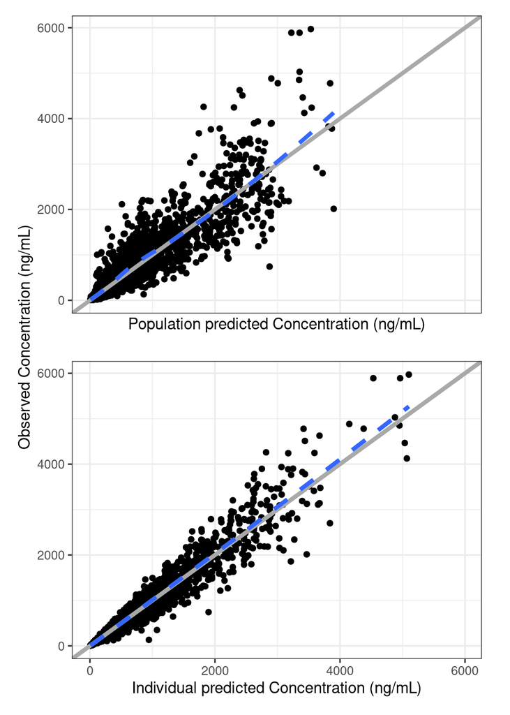

DV vs PRED and IPRED log scale

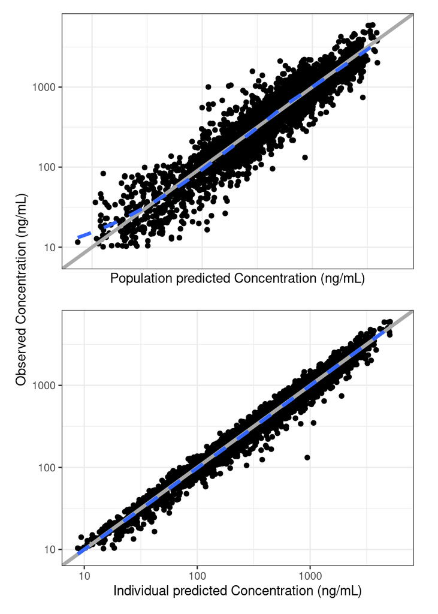

## CWRES plots

CWRES vs PRED, time and time after dose.

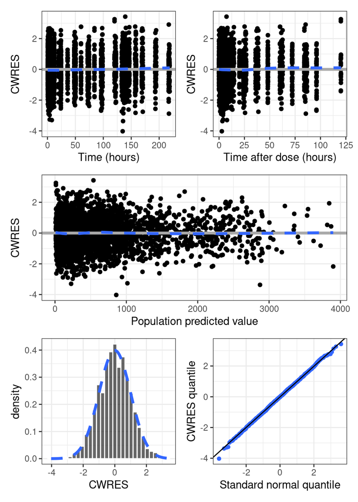

# EBEs-based diagnostics

## ETA pairs plot

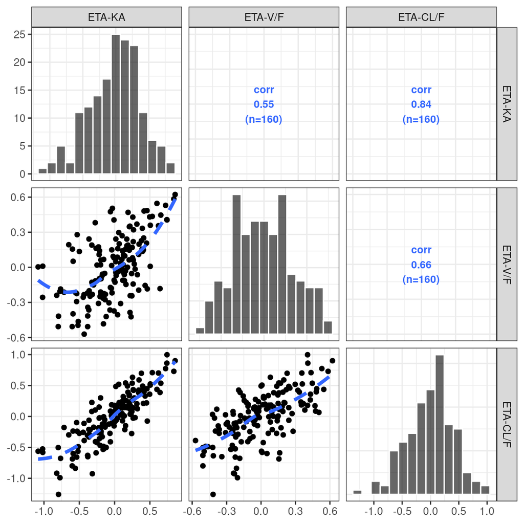

## ETA vs continous covariates

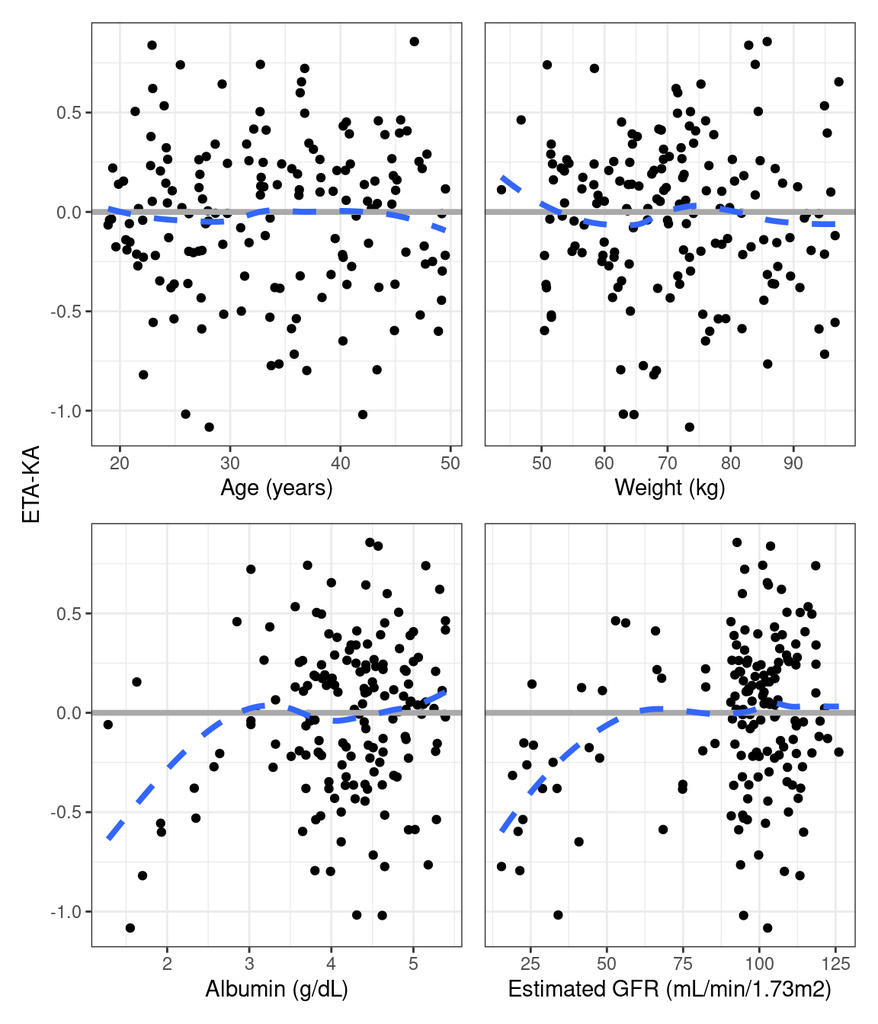

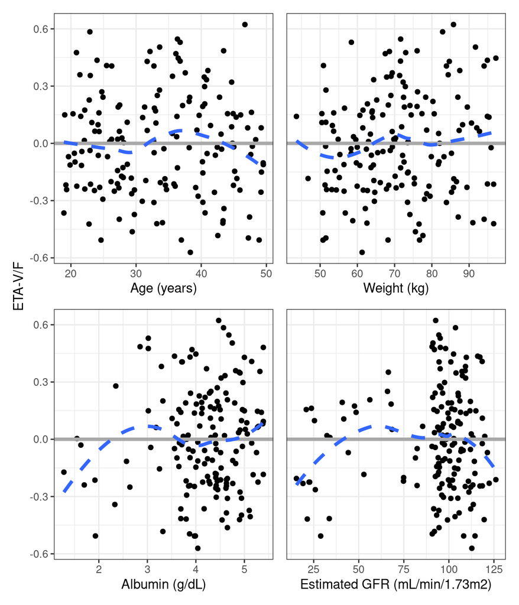

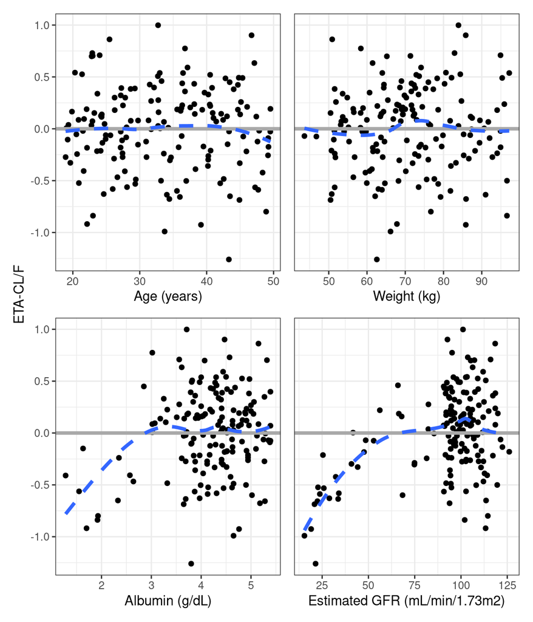

## ETA vs categorical covariates

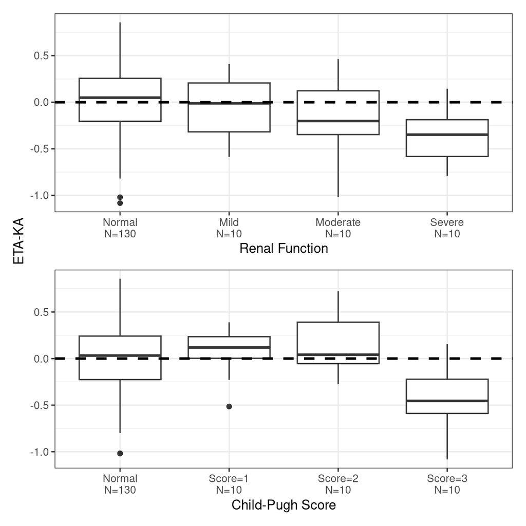

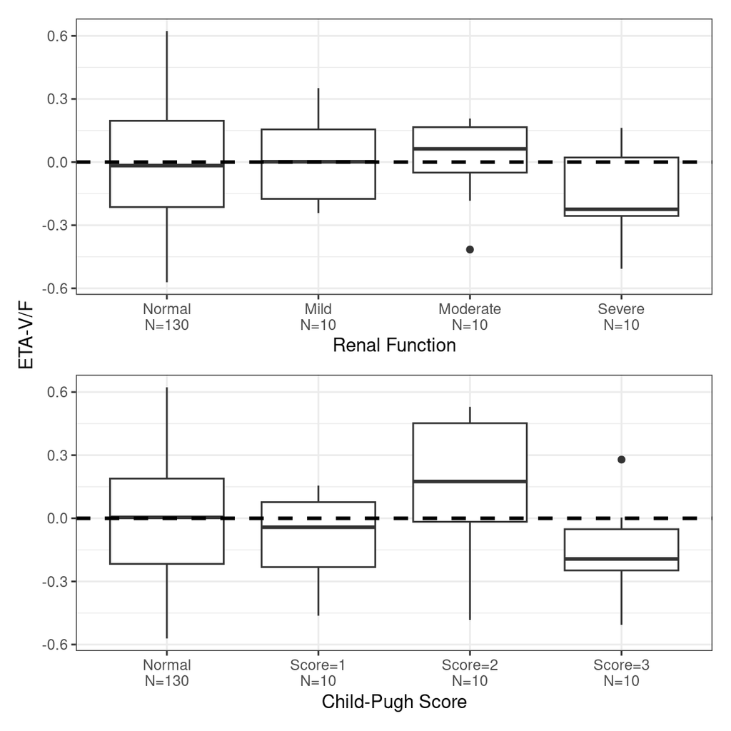

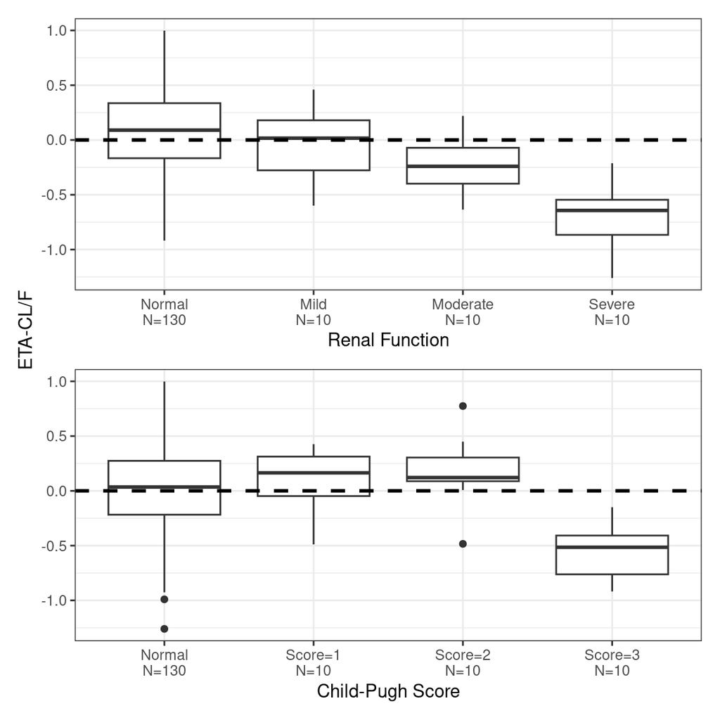

# Session details

```
## [1] "Fri Mar 28 15:29:41 2025"
```

```
## [1] "3.3.0"
```